# Access locations and times of Sandhill Crane encounters

For this challenge, you will use a database called the [Global Biodiversity Information Facility (GBIF)](https://www.gbif.org/). GBIF is compiled from species observation data all over the world, and includes everything from museum specimens to photos taken by citizen scientists in their backyards.

**Explore GBIF:** Before your get started, go to the [GBIF occurrences search page](https://www.gbif.org/occurrence/search) and explore the data.

See also:

- [Crane Maps](https://github.com/byandell-envsys/craneMaps)
- [Sandhill Crane](https://github.com/earthlab-education/species-distribution-coding-challenge-byandell/blob/main/notebooks/sandhill_crane.qmd)

> **Contribute to open data**

> You can get your own observations added to GBIF using [iNaturalist](https://www.inaturalist.org/)!

### Set up your code to prepare for download

We will be getting data from a source called [GBIF (Global Biodiversity Information Facility)](https://www.gbif.org/). We need a package called `pygbif` to access the data, which may not be included in your environment. Install it by running the cell below:

```python
conda list pygbif
```

```python
%pip install -q -e ..
```

```python
from landmapyr.initial import create_data_dir, robust_code
```

```python
from landmapyr.gbif import gbif_credentials, gbif_species_key
from landmapyr.gbif import download_gbif, load_gbif, gbif_monthly
from landmapyr.gbif import ecoregions, join_ecoregions_monthly
from landmapyr.gbif import count_by_ecoregions
from landmapyr.gbif import simplify_ecoregions_gdf, join_occurrence
```

**Import packages:** In the imports cell, we’ve included some packages that you will need. Add imports for packages that will help you:

- Work with reproducible file paths
- Work with tabular data

For now, run `gbif.py`. Soon, incorporate it into `landmapyr` package.

```python
robust_code()
data_dir = create_data_dir('species')
gbif_dir = create_data_dir('species/gbif_sandhill')
gbif_dir
```

```
'/Users/brianyandell/earth-analytics/data/species/gbif_sandhill'
```

### Register and log in to GBIF

You will need a [GBIF account](https://www.gbif.org/) to complete this challenge. You can use your GitHub account to authenticate with GBIF. Then, run the following code to save your credentials on your computer.

> **Warning**

> Your email address **must** match the email you used to sign up for GBIF!

> **Tip**

> If you accidentally enter your credentials wrong, you can set `reset_credentials=True` instead of `reset_credentials=False`.

```python
gbif_credentials(False)
```

### Get the species key

> ** Your task**
> 1. Replace the `species_name` with the name of the species you want to look up
> 2. Run the code to get the species key

```python
species_name, species_key = gbif_species_key('grus canadensis')
species_name, species_key
```

```
('Antigone canadensis', 2474953)
```

### Download data from GBIF

```python
gbif_path = download_gbif(gbif_dir, species_key)
gbif_path
```

```
'/Users/brianyandell/earth-analytics/data/species/gbif_sandhill/0012336-260423192947929.zip'
```

### Load the GBIF data into Python

**Load GBIF data:**

I copied from [Lauren Alexandra](https://github.com/lauren-alexandra/lauren-alexandra.github.io/blob/main/willow-flycatcher-distribution/willow-flycatcher-distribution.ipynb) and Lauren Gleason

```python
gbif_df = load_gbif(gbif_path)
gbif_df.head()
```

| gbifID | countryCode | stateProvince | decimalLatitude | decimalLongitude | month | year |
| --- | --- | --- | --- | --- | --- | --- |
| 4103735033 | US | NaN | 40.6437 | -98.8950 | 3 | 2023 |
| 4953718975 | US | NaN | 31.5633 | -109.7160 | 11 | 2023 |
| 4135517029 | US | NaN | 42.3291 | -84.2403 | 5 | 2023 |
| 4953718976 | US | NaN | 32.0840 | -109.0510 | 1 | 2023 |
| 4953718225 | US | NaN | 32.0840 | -109.0510 | 3 | 2023 |

### Canada Breeding Locations

```python
ac_CA = gbif_df.loc[gbif_df['countryCode'] == 'CA']
ac_CA.value_counts()
```

```
countryCode  stateProvince     decimalLatitude  decimalLongitude  month  year
CA           Ontario           41.955400        -82.514000        5      2023    395
                               42.038967        -82.509125        5      2023    217
             British Columbia  49.100000        -123.185000       1      2023    183
             Ontario           44.350597        -79.883620        4      2023    168
             British Columbia  49.100000        -123.185000       12     2023    159
                                                                                ...
             Ontario           43.349340        -80.209730        5      2023      1
                               43.349964        -80.375656        4      2023      1
                               43.353832        -79.860730        4      2023      1
                               43.354767        -81.499330        4      2023      1
             Yukon Territory   69.596910        -140.185060       6      2023      1
Name: count, Length: 15708, dtype: int64
```

### US Breeding Locations

```python
ac_US = gbif_df.loc[gbif_df['countryCode'] == 'US']
ac_US.value_counts()
```

```
countryCode  stateProvince  decimalLatitude  decimalLongitude  month  year
US           Ohio           41.627710        -83.191890        5      2023    1576
                            41.645070        -83.263720        5      2023     505
             Wisconsin      43.033360        -89.351380        4      2023     336
             Arizona        31.561499        -109.720020       1      2023     321
             Ohio           41.626520        -83.188970        5      2023     312
                                                                              ...
             Michigan       42.253153        -85.857013        8      2023       1
                            42.253130        -85.988390        5      2023       1
                            42.253110        -83.695220        9      2023       1
                            42.253010        -85.302475        3      2023       1
             Wyoming (WY)   44.610549        -110.220852       7      2023       1
Name: count, Length: 103892, dtype: int64
```

## Convert GBIF data to a GeoDataFrame by Month

```python
monthly_gdf = gbif_monthly(gbif_df)
monthly_gdf
```

| gbifID | year | month | geometry |
| --- | --- | --- | --- |
| 4103735033 | 2023 | 3 | POINT (-98.895 40.6437) |
| 4953718975 | 2023 | 11 | POINT (-109.716 31.5633) |
| 4135517029 | 2023 | 5 | POINT (-84.2403 42.3291) |
| 4953718976 | 2023 | 1 | POINT (-109.051 32.084) |
| 4953718225 | 2023 | 3 | POINT (-109.051 32.084) |
| ... | ... | ... | ... |
| 4159135015 | 2023 | 5 | POINT (-82.54347 41.98161) |
| 4884744706 | 2023 | 7 | POINT (-86.14826 42.53785) |
| 4159295666 | 2023 | 5 | POINT (-80.4592 42.5761) |
| 4408876179 | 2023 | 7 | POINT (-151.51888 59.63738) |
| 4409335777 | 2023 | 8 | POINT (-151.52234 59.64154) |

313542 rows × 3 columns

### Download and save ecoregion boundaries

Ecoregions represent boundaries formed by biotic and abiotic conditions: geology, landforms, soils, vegetation, land use, wildlife, climate, and hydrology.

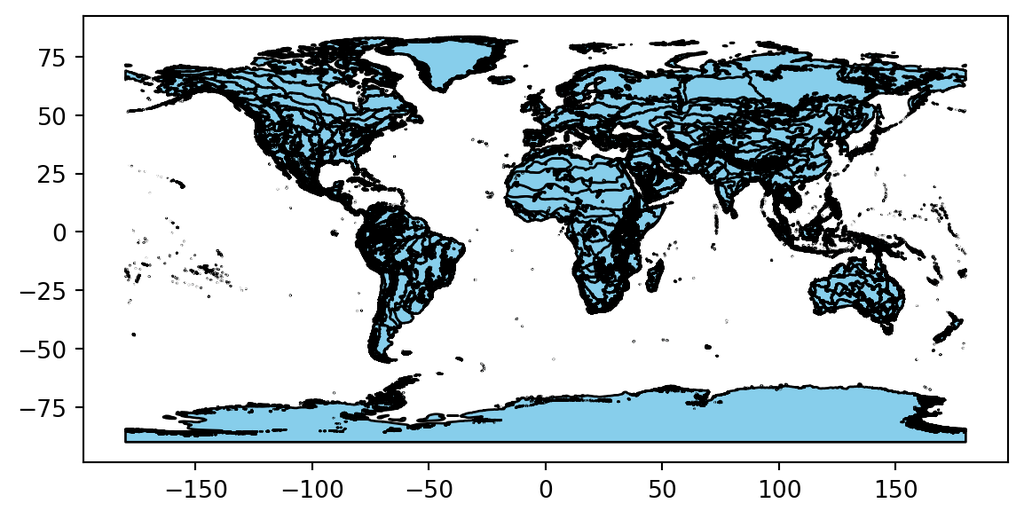

Figure 1

```python
ecoregions_gdf = ecoregions(data_dir)
ecoregions_gdf.plot(edgecolor='black', color='skyblue')
```

```python
%%bash
find ~/earth-analytics/data/species -name '*.shp'
```

```python
%store ecoregions_gdf monthly_gdf
```

```
Stored 'ecoregions_gdf' (GeoDataFrame)
Stored 'monthly_gdf' (GeoDataFrame)
```

Identify the ecoregion for each observation

```python
gbif_ecoregion_gdf = join_ecoregions_monthly(ecoregions_gdf, monthly_gdf)
gbif_ecoregion_gdf
```

| ecoregion | year | month | name |
| --- | --- | --- | --- |
| 4 | 2023 | 8 | Ahklun and Kilbuck Upland Tundra |
| 4 | 2023 | 7 | Ahklun and Kilbuck Upland Tundra |
| 4 | 2023 | 7 | Ahklun and Kilbuck Upland Tundra |
| 4 | 2023 | 7 | Ahklun and Kilbuck Upland Tundra |
| 4 | 2023 | 7 | Ahklun and Kilbuck Upland Tundra |
| ... | ... | ... | ... |
| 833 | 2023 | 4 | Northern Rockies conifer forests |
| 833 | 2023 | 5 | Northern Rockies conifer forests |
| 833 | 2023 | 5 | Northern Rockies conifer forests |
| 833 | 2023 | 6 | Northern Rockies conifer forests |
| 833 | 2023 | 5 | Northern Rockies conifer forests |

307693 rows × 3 columns

Count the observations in each ecoregion each month

```python
occurrence_df = count_by_ecoregions(gbif_ecoregion_gdf, 'ecoregion', 'name', 'month')
occurrence_df
```

| ecoregion | month | occurrences | norm_occurrences |
| --- | --- | --- | --- |
| 4 | 7 | 5 | 0.004427 |
| 9 | 5 | 3 | 0.000745 |
|  | 6 | 2 | 0.001061 |
|  | 8 | 8 | 0.004741 |
|  | 9 | 13 | 0.007170 |
| ... | ... | ... | ... |
| 833 | 7 | 169 | 0.004581 |
|  | 8 | 173 | 0.004080 |
|  | 9 | 131 | 0.002875 |
|  | 10 | 95 | 0.001874 |
|  | 11 | 25 | 0.000438 |

788 rows × 2 columns

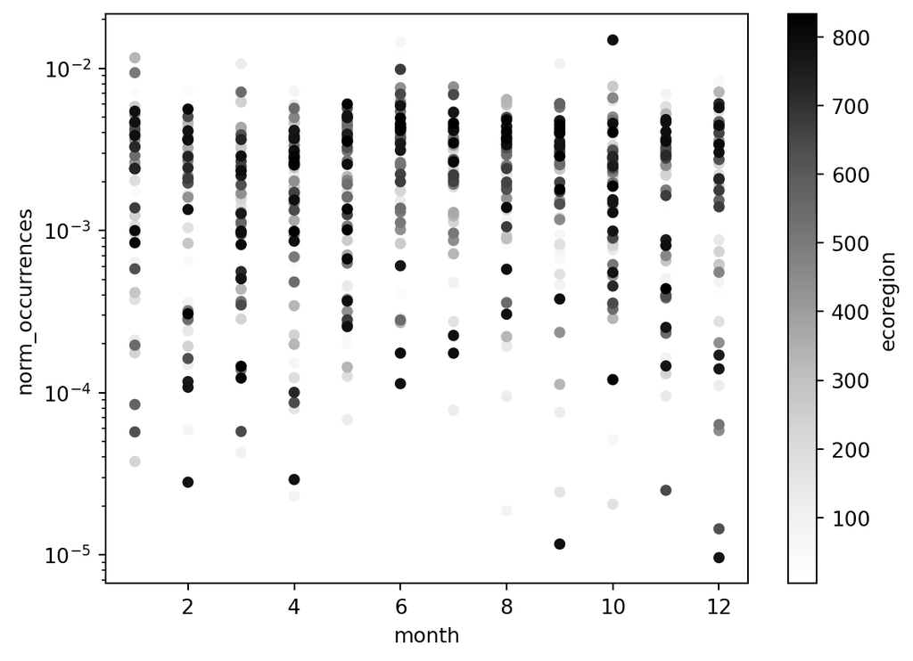

Figure 2

```python
# plot to check distrubions
occurrence_df.reset_index().plot.scatter(
    x='month', y='norm_occurrences', c='ecoregion',
    logy=True
)
```

Create a simplified GeoDataFrame for plot

```python
ecoregions_gdf = simplify_ecoregions_gdf(ecoregions_gdf)
ecoregions_gdf
```

| ecoregion | name | area | geometry |
| --- | --- | --- | --- |
| 0 | Adelie Land tundra | 0.038948 | MULTIPOLYGON EMPTY |
| 1 | Admiralty Islands lowland rain forests | 0.170599 | POLYGON ((16411777.375 -229101.376, 16384825.7... |
| 2 | Aegean and Western Turkey sclerophyllous and m... | 13.844952 | MULTIPOLYGON (((3391149.749 4336064.109, 33846... |
| 3 | Afghan Mountains semi-desert | 1.355536 | MULTIPOLYGON (((7369001.698 4093509.259, 73168... |
| 4 | Ahklun and Kilbuck Upland Tundra | 8.196573 | MULTIPOLYGON (((-17930832.005 8046779.358, -17... |
| ... | ... | ... | ... |
| 842 | Sulawesi lowland rain forests | 9.422097 | MULTIPOLYGON (((14113374.546 501721.962, 14128... |
| 843 | East African montane forests | 5.010930 | MULTIPOLYGON (((4298787.669 -137583.786, 42727... |
| 844 | Eastern Arc forests | 0.890325 | MULTIPOLYGON (((4267432.68 -493759.165, 428533... |
| 845 | Borneo montane rain forests | 9.358407 | MULTIPOLYGON (((13126956.393 539092.917, 13136... |
| 846 | Kinabalu montane alpine meadows | 0.352694 | POLYGON ((12981819.186 696445.445, 12997053.80... |

847 rows × 3 columns

```python
%store gbif_path
%who
```

```
Stored 'gbif_path' (str)
ac_CA    ac_US   count_by_ecoregions     create_data_dir     data_dir    download_gbif   ecoregions  ecoregions_gdf  gbif_credentials
gbif_df  gbif_dir    gbif_ecoregion_gdf  gbif_monthly    gbif_path   gbif_species_key    join_ecoregions_monthly     join_occurrence     load_gbif
monthly_gdf  occurrence_df   ojs_define  robust_code     simplify_ecoregions_gdf     species_key     species_name
```

Mapping monthly distribution

```python
occurrence_gdf = join_occurrence(ecoregions_gdf, occurrence_df)
occurrence_gdf
```

| ecoregion | month | name | area | geometry | norm_occurrences |
| --- | --- | --- | --- | --- | --- |
| 4 | 7 | Ahklun and Kilbuck Upland Tundra | 8.196573 | MULTIPOLYGON (((-17930832.005 8046779.358, -17... | 0.004427 |
| 9 | 5 | Alaska-St. Elias Range tundra | 28.388010 | MULTIPOLYGON (((-16886232.729 9049093.235, -16... | 0.000745 |
|  | 6 | Alaska-St. Elias Range tundra | 28.388010 | MULTIPOLYGON (((-16886232.729 9049093.235, -16... | 0.001061 |
|  | 8 | Alaska-St. Elias Range tundra | 28.388010 | MULTIPOLYGON (((-16886232.729 9049093.235, -16... | 0.004741 |
|  | 9 | Alaska-St. Elias Range tundra | 28.388010 | MULTIPOLYGON (((-16886232.729 9049093.235, -16... | 0.007170 |
| ... | ... | ... | ... | ... | ... |
| 833 | 7 | Northern Rockies conifer forests | 35.905513 | POLYGON ((-13358313.218 7236575.932, -13331349... | 0.004581 |
|  | 8 | Northern Rockies conifer forests | 35.905513 | POLYGON ((-13358313.218 7236575.932, -13331349... | 0.004080 |
|  | 9 | Northern Rockies conifer forests | 35.905513 | POLYGON ((-13358313.218 7236575.932, -13331349... | 0.002875 |
|  | 10 | Northern Rockies conifer forests | 35.905513 | POLYGON ((-13358313.218 7236575.932, -13331349... | 0.001874 |
|  | 11 | Northern Rockies conifer forests | 35.905513 | POLYGON ((-13358313.218 7236575.932, -13331349... | 0.000438 |

788 rows × 4 columns

```python
%store occurrence_gdf
```

```
Stored 'occurrence_gdf' (GeoDataFrame)
```

### Plot monthly distribution

#### Static Plot

[figure not shown]

Figure 3

```python
from landmapyr.plots import plot_occurrence
plot_occurrence(occurrence_gdf, ncols=1)
```

#### Optional Dynamic Plot

```python
from landmapyr.hv_plots import hvplot_occurrence
occurrence_hvplot = hvplot_occurrence(occurrence_gdf,
  title="Antigone canadensis Sandhill Crane Migration")
# Save the plot
occurrence_hvplot.save('sandhill-crane-migration.html', embed=True)
```

```
WARNING:W-1005 (FIXED_SIZING_MODE): 'fixed' sizing mode requires width and height to be set: figure(id='bae28123-b037-49e1-8444-4db65e058559', ...)
```

```python
occurrence_hvplot
```

Figure 4

[output not shown]

[interactive chart not shown]

If not shown, see Dynamic Images from Environmental Data Analytics Projects.

#### April Observations

```python
occurrence_gdf_complete = occurrence_gdf.reset_index()

april_occ = occurrence_gdf_complete.loc[occurrence_gdf_complete['month'] == 4].sort_values(by=['norm_occurrences'], ascending=False)

april_occ_top_5 = april_occ[0:5]
april_occ_bottom_5 = april_occ[-5:]
```

```python
# Top Five Ecoregions

april_occ_top_5
```

|  | ecoregion | month | name | area | geometry | norm_occurrences |
| --- | --- | --- | --- | --- | --- | --- |
| 115 | 81 | 4 | British Columbia coastal conifer forests | 14.653986 | MULTIPOLYGON (((-14364688.43 7420408.623, -143... | 0.007219 |
| 225 | 149 | 4 | Central Tallgrass prairie | 36.779324 | POLYGON ((-10534926.556 5619565.277, -10517878... | 0.005960 |
| 557 | 546 | 4 | Palouse prairie | 9.866972 | MULTIPOLYGON (((-12951912.056 5827151.995, -12... | 0.005675 |
| 257 | 173 | 4 | Colorado Rockies forests | 15.113154 | MULTIPOLYGON (((-12173003.318 4534115.934, -12... | 0.005394 |
| 487 | 471 | 4 | New England-Acadian forests | 38.509900 | MULTIPOLYGON (((-7182650.847 5741141.666, -715... | 0.004976 |

```python
# Bottom Five Ecoregions

april_occ_bottom_5
```

|  | ecoregion | month | name | area | geometry | norm_occurrences |
| --- | --- | --- | --- | --- | --- | --- |
| 611 | 639 | 4 | Sonoran desert | 21.416224 | MULTIPOLYGON (((-12499491.62 3383569.444, -124... | 0.000087 |
| 136 | 88 | 4 | California coastal sage and chaparral | 3.172258 | MULTIPOLYGON (((-12820829.454 3243992.707, -12... | 0.000087 |
| 237 | 162 | 4 | Chihuahuan desert | 46.807295 | MULTIPOLYGON (((-12343440.455 3790837.437, -12... | 0.000079 |
| 711 | 783 | 4 | Western Gulf coastal grasslands | 8.340400 | POLYGON ((-10826974.582 3185079.852, -10843709... | 0.000029 |
| 127 | 87 | 4 | California Central Valley grasslands | 4.727694 | POLYGON ((-13595834.408 4868653.384, -13554815... | 0.000023 |